# p8131_stl2137_hw5

# Problem 1

```r
### Load in crab data

crab_dat <- read.table("/Users/SabrinaLin/Documents/Spring_20_Biostat_Methods_2/Homework/p8131_stl2137_hw5/HW5-crab.txt", header = TRUE) %>%
  janitor::clean_names()
```

## Part A

```r
### M1 model
crab_m1_mod <- glm(sa ~ w, family = poisson(link = "log"), data = crab_dat)
summary(crab_m1_mod)
```

```
##
## Call:
## glm(formula = sa ~ w, family = poisson(link = "log"), data = crab_dat)
##
## Deviance Residuals:
##     Min       1Q   Median       3Q      Max
## -2.8526  -1.9884  -0.4933   1.0970   4.9221
##
## Coefficients:
##             Estimate Std. Error z value Pr(>|z|)
## (Intercept) -3.30476    0.54224  -6.095  1.1e-09 ***
## w            0.16405    0.01997   8.216  < 2e-16 ***
## ---
## Signif. codes:  0 '***' 0.001 '**' 0.01 '*' 0.05 '.' 0.1 ' ' 1
##
## (Dispersion parameter for poisson family taken to be 1)
##
##     Null deviance: 632.79  on 172  degrees of freedom
## Residual deviance: 567.88  on 171  degrees of freedom
## AIC: 927.18
##
## Number of Fisher Scoring iterations: 6
```

```r
### Goodness of fit
crab_m1_pval <- pchisq(crab_m1_mod$deviance, df = crab_m1_mod$df.residual, lower.tail = FALSE)
```

- 0.16405 is the log rate ratio of number of satellites with every 1 unit increase in carapace width.
- With a p-value of 4.49096410^{-44}, we reject the null hypothesis and conclude that the model does not fit the data.

## Part B

```r
### M2 model
crab_m2_mod <- glm(sa ~ w + wt, family = poisson(link = "log"), data = crab_dat)
summary(crab_m2_mod)
```

```
##
## Call:
## glm(formula = sa ~ w + wt, family = poisson(link = "log"), data = crab_dat)
##
## Deviance Residuals:
##     Min       1Q   Median       3Q      Max
## -2.9308  -1.9705  -0.5481   0.9700   4.9905
##
## Coefficients:
##             Estimate Std. Error z value Pr(>|z|)
## (Intercept) -1.29168    0.89929  -1.436  0.15091
## w            0.04590    0.04677   0.981  0.32640
## wt           0.44744    0.15864   2.820  0.00479 **
## ---
## Signif. codes:  0 '***' 0.001 '**' 0.01 '*' 0.05 '.' 0.1 ' ' 1
##
## (Dispersion parameter for poisson family taken to be 1)
##
##     Null deviance: 632.79  on 172  degrees of freedom
## Residual deviance: 559.89  on 170  degrees of freedom
## AIC: 921.18
##
## Number of Fisher Scoring iterations: 6
```

```r
### M2 vs M1
test.stat = crab_m1_mod$deviance - crab_m2_mod$deviance
df = 171 - 170
pval = 1 - pchisq(test.stat, df = df)
pval
```

```
## [1] 0.004694838
```

- With a p-value of 0.32640 compared to $\alpha = 0.05$, carapace width is an insignifcant variable. 0.04590 is the log rate ratio of number of satellites with every 1 unit increase in carapace width, keeping weight constant.
- 0.44744 is the log rate ratio of the number of satellites with every 1 unit increase in weight, keeping carapace width constant.
- With a p-value of 0.0046948, we reject the null hypothesis and conclude that M2, the bigger model, is the model we should continue with.

## Part C

```r
m2_dispersion_mod <- glm(sa ~ w + wt, family = quasi(link = "log", variance = mu), data = crab_dat)
summary(m2_dispersion_mod)
```

```
##
## Call:
## glm(formula = sa ~ w + wt, family = quasi(link = "log", variance = mu),
##     data = crab_dat)
##
## Deviance Residuals:
##     Min       1Q   Median       3Q      Max
## -2.9308  -1.9705  -0.5481   0.9700   4.9905
##
## Coefficients:
##             Estimate Std. Error t value Pr(>|t|)
## (Intercept) -1.29168    1.59771  -0.808    0.420
## w            0.04590    0.08309   0.552    0.581
## wt           0.44744    0.28184   1.588    0.114
##
## (Dispersion parameter for quasi family taken to be 3.156449)
##
##     Null deviance: 632.79  on 172  degrees of freedom
## Residual deviance: 559.89  on 170  degrees of freedom
## AIC: NA
##
## Number of Fisher Scoring iterations: 6
```

```r
## Checking that traditional way also works
res.m2.disp <- residuals(crab_m2_mod, type = 'pearson', data = crab_dat)
G1.m2 <- sum(res.m2.disp^2)
pval = 1 - pchisq(G1.m2, df = 170)
phi = G1.m2/170
#phi

#summary(crab_m2_mod , dispersion = phi)
```

- With a p-value of 0.581 compared to $\alpha = 0.05$, the carapace width variable is insignificant. 0.04590 is the log rate ratio of number of satellites with every 1 unit increase in carapace width, holding weight constant.
- With a p-value of 0.114 compared to $\alpha = 0.05$, the weight variable is insignificant. 0.44744 is the log rato ratio of number of satellites with every 1 unit increase in weight, holding carapace width constant.

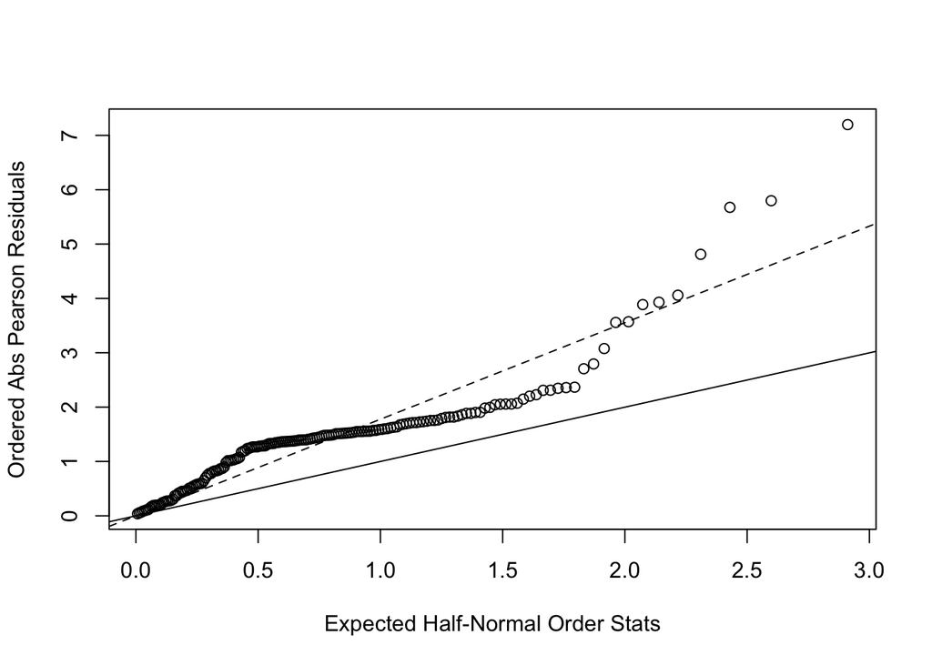

```r
### Half normal plot
tilde.phi = crab_m2_mod$deviance/crab_m2_mod$df.residual
res = residuals(crab_m2_mod, type = 'pearson')
plot(qnorm((173+1:173+0.5)/(2*173+1.125)),sort(abs(res)),xlab='Expected Half-Normal Order Stats',ylab='Ordered Abs Pearson Residuals')
abline(a=0,b=1)
abline(a=0,b=sqrt(phi),lty=2)
```

As demonstrated by the plot, the data does not follow a phi of 1, showing that there is overdispersion.

# Problem 2

```r
### Load parasite data

parasite_dat <- read.table("/Users/SabrinaLin/Documents/Spring_20_Biostat_Methods_2/Homework/p8131_stl2137_hw5/HW5-parasite.txt", header = TRUE) %>%
  janitor::clean_names() %>%
  mutate(
    area = as.factor(area),
    year = as.factor(year)
  )
```

## Part A

```r
parasite_mod <- glm(intensity ~ area + year + length, family = poisson(link = "log"), data = parasite_dat)

summary(parasite_mod)
```

```
##
## Call:
## glm(formula = intensity ~ area + year + length, family = poisson(link = "log"),
##     data = parasite_dat)
##
## Deviance Residuals:
##     Min       1Q   Median       3Q      Max
## -9.3632  -2.7158  -2.0142  -0.4731  30.2492
##
## Coefficients:
##               Estimate Std. Error z value Pr(>|z|)
## (Intercept)  2.6431709  0.0542838  48.692  < 2e-16 ***
## area2       -0.2119557  0.0491691  -4.311 1.63e-05 ***
## area3       -0.1168602  0.0428296  -2.728  0.00636 **
## area4        1.4049366  0.0356625  39.395  < 2e-16 ***
## year2000     0.6702801  0.0279823  23.954  < 2e-16 ***
## year2001    -0.2181393  0.0287535  -7.587 3.29e-14 ***
## length      -0.0284228  0.0008809 -32.265  < 2e-16 ***
## ---
## Signif. codes:  0 '***' 0.001 '**' 0.01 '*' 0.05 '.' 0.1 ' ' 1
##
## (Dispersion parameter for poisson family taken to be 1)
##
##     Null deviance: 25797  on 1190  degrees of freedom
## Residual deviance: 19153  on 1184  degrees of freedom
##   (63 observations deleted due to missingness)
## AIC: 21089
##
## Number of Fisher Scoring iterations: 7
```

- -0.2119557 is the log rate ratio of the number of parasites when going from area 2 to area 1, holding all other variables constant.
- -0.1168602 is the log rate ratio of the number of parasites when going from area 3 to area 1, holding all other variables constant.
- 1.4049366 is the log rate ratio of the number of parasites when going from area 4 to area 1, holding all other variables constant.
- 0.6702801 is the log rate ratio of the number of parasites when going from the year 2000 to the year 1999, holding all other variables constant.
- -0.2181393 is the log rate ratio of the number of parasites when going from the year 2001 to the year 1999, holding all other variables constant.
- -0.0284228 is the log rate ratio of the number of parasites for every 1 unit increase in length, holding all other variables constant.

## Part B

```r
parasite_pval <- pchisq(parasite_mod$deviance, df = parasite_mod$df.residual, lower.tail = FALSE)
```

With a p-value of 0, we reject the null hypothesis and conclude that the model does not fit the data.

## Part C

3. Provide an interpretation for each model parameter in terms of the problem.

```r
### what should the given be? area? length?

parasite_zero_mod <- zeroinfl(intensity ~ year + length | area, data = parasite_dat)
summary(parasite_zero_mod)
```

```
##
## Call:
## zeroinfl(formula = intensity ~ year + length | area, data = parasite_dat)
##
## Pearson residuals:
##     Min      1Q  Median      3Q     Max
## -1.5077 -0.7131 -0.6447 -0.2369 26.2175
##
## Count model coefficients (poisson with log link):
##               Estimate Std. Error z value Pr(>|z|)
## (Intercept)  4.6630528  0.0459573 101.465  < 2e-16 ***
## year2000     0.4214742  0.0278972  15.108  < 2e-16 ***
## year2001     0.0988372  0.0286162   3.454 0.000553 ***
## length      -0.0438777  0.0009298 -47.193  < 2e-16 ***
##
## Zero-inflation model coefficients (binomial with logit link):
##              Estimate Std. Error z value Pr(>|z|)
## (Intercept)  0.001796   0.121809   0.015    0.988
## area2        0.746780   0.183065   4.079 4.52e-05 ***
## area3        0.680876   0.161795   4.208 2.57e-05 ***
## area4       -0.882655   0.180987  -4.877 1.08e-06 ***
## ---
## Signif. codes:  0 '***' 0.001 '**' 0.01 '*' 0.05 '.' 0.1 ' ' 1
##
## Number of iterations in BFGS optimization: 15
## Log-likelihood: -7563 on 8 Df
```

### Count Model Coefficient Interpretations

- 0.4214742 is the log rate ratio of the number of parasites when going from the year 2000 to the year 1999 given that the fish strain is susceptible to parasites, holding all other variables constant.
- 0.0988372 is the log rate ratio of the number of parasites when going from the year 2001 to the year 1999 given that the fish strain is susceptible to parasites, holding all other variables constant.
- -0.0438777 is the log rate ratio of the number of parasites for every 1 unit increase in length given that the fish strain is susceptible to parasites, holding all other variables constant.

### Zero-inflation Model Coefficient Interpretations

- 0.7467803 is the log odds ratio of not being the fish strain susceptible to parasites when comparing area 2 to area 1.
- 0.680876 is the log odds ratio of not being the fish strain susceptible to parasites when comparing area 3 to area 1.
- -0.8826545 is the log odds ratio of not being the fish strain susceptible to parasites when comparing area 4 to area 1.